# Lab 4 Coding Basics, Style and Data Read/Write

Author

Dylan Mackler

# Chapter 2 Workflow: basics

## 2.1 Coding Basics

```r
1 / 200 * 30
```

```
[1] 0.15
```

```
#> [1] 0.15
```

```r
(59 + 73 + 2) / 3
```

```
[1] 44.66667
```

```
#> [1] 44.66667
```

```r
sin(pi / 2)
```

```
[1] 1
```

```
#> [1] 1
```

```r
x <- 3 * 4
```

```r
primes <- c(2, 3, 5, 7, 11, 13)
```

```r
primes * 2
```

```
[1]  4  6 10 14 22 26
```

```
#> [1]  4  6 10 14 22 26
```

```r
primes - 1
```

```
[1]  1  2  4  6 10 12
```

```
#> [1]  1  2  4  6 10 12
```

## 2.2 Comments

```r
# create vector of primes
primes <- c(2, 3, 5, 7, 11, 13)

# multiply primes by 2
primes * 2
```

```
[1]  4  6 10 14 22 26
```

```
#> [1]  4  6 10 14 22 26
```

## 2.3 What’s in a name?

```r
x
```

```
[1] 12
```

```
#> [1] 12
```

```r
this_is_a_really_long_name <- 2.5
```

```r
r_rocks <- 2^3
```

## 2.4 Calling functions

```r
seq(from = 1, to = 10)
```

```
 [1]  1  2  3  4  5  6  7  8  9 10
```

```
#>  [1]  1  2  3  4  5  6  7  8  9 10
```

```r
seq(1, 10)
```

```
 [1]  1  2  3  4  5  6  7  8  9 10
```

```
#>  [1]  1  2  3  4  5  6  7  8  9 10
```

```r
x <- "12"
```

## 2.5 Exercises

### 1.

The issue is that `my_variable` and `my_varıable` are not the same name. The second version uses a dotless ‘ı’, instead of the standard lowercase ‘i’.

```r
# fixed version
my_variable <- 10
my_variable
```

```
[1] 10
```

### 2.

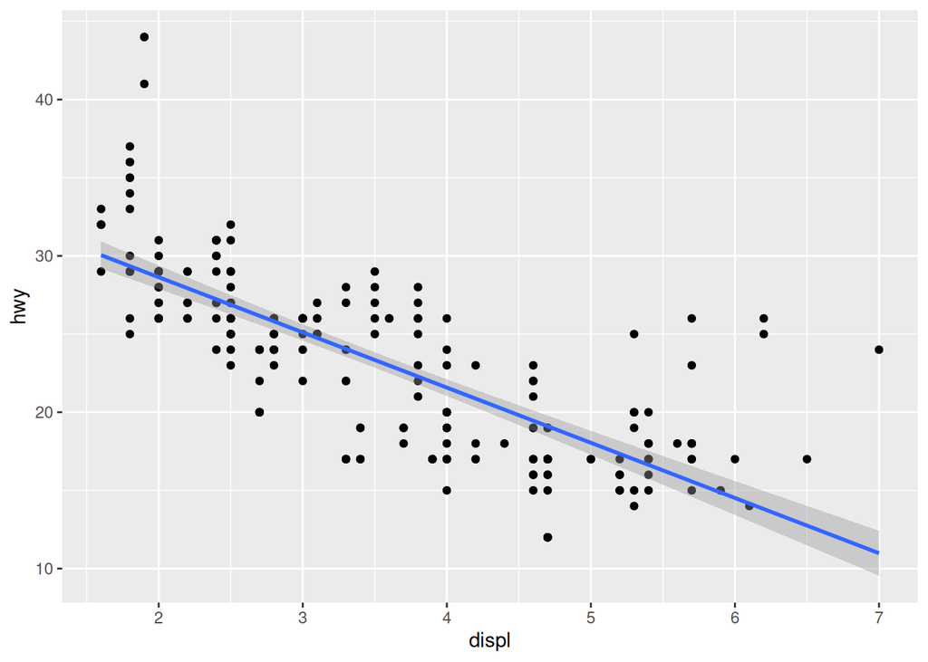

```r
library(tidyverse)

ggplot(data = mpg) +
  geom_point(mapping = aes(x = displ, y = hwy)) +
  geom_smooth(mapping = aes(x = displ, y = hwy), method = "lm")
```

### 3.

This command opens the Keyboard Shortcuts reference panel which displays a searchable list of available shortcuts for the current app, helping you work more efficiently. To reach the same panel using the menus, you can go to the Help tab in the ribbon and select Keyboard Shortcuts. This provides the same overview without using a key combination.

### 4.

```r
my_bar_plot <- ggplot(mpg, aes(x = class)) +
  geom_bar()
my_scatter_plot <- ggplot(mpg, aes(x = cty, y = hwy)) +
  geom_point()
ggsave(filename = "mpg-plot.png", plot = my_bar_plot)
```

The bar plot showing the count of cars by class is saved as *mpg-plot.png* because the ggsave() function was called with plot = my_bar_plot. The scatter plot was created but not saved, since it was not referenced in the ggsave() call.

# Chapter 4 Workflow: code style

```r
library(tidyverse)
library(nycflights13)
```

## 4.1 Names

```r
# Strive for:
short_flights <- flights |> filter(air_time < 60)

# Avoid:
SHORTFLIGHTS <- flights |> filter(air_time < 60)
```

## 4.2 Spaces

```r
a <- 3
b <- 2
d <- 5
# Strive for
z <- (a + b)^2 / d

# Avoid
z<-( a + b ) ^ 2/d
```

```r
x <- c(4, 7, NA, 10, 3)
# Strive for
mean(x, na.rm = TRUE)
```

```
[1] 6
```

```r
# Avoid
mean (x ,na.rm=TRUE)
```

```
[1] 6
```

```r
flights |>
  mutate(
    speed      = distance / air_time,
    dep_hour   = dep_time %/% 100,
    dep_minute = dep_time %%  100
  )
```

```
# A tibble: 336,776 × 22
    year month   day dep_time sched_dep_time dep_delay arr_time sched_arr_time
   <int> <int> <int>    <int>          <int>     <dbl>    <int>          <int>
 1  2013     1     1      517            515         2      830            819
 2  2013     1     1      533            529         4      850            830
 3  2013     1     1      542            540         2      923            850
 4  2013     1     1      544            545        -1     1004           1022
 5  2013     1     1      554            600        -6      812            837
 6  2013     1     1      554            558        -4      740            728
 7  2013     1     1      555            600        -5      913            854
 8  2013     1     1      557            600        -3      709            723
 9  2013     1     1      557            600        -3      838            846
10  2013     1     1      558            600        -2      753            745
# ℹ 336,766 more rows
# ℹ 14 more variables: arr_delay <dbl>, carrier <chr>, flight <int>,
#   tailnum <chr>, origin <chr>, dest <chr>, air_time <dbl>, distance <dbl>,
#   hour <dbl>, minute <dbl>, time_hour <dttm>, speed <dbl>, dep_hour <dbl>,
#   dep_minute <dbl>
```

## 4.3 Pipes

```r
# Strive for
flights |>
  filter(!is.na(arr_delay), !is.na(tailnum)) |>
  count(dest)
```

```
# A tibble: 104 × 2
   dest      n
   <chr> <int>
 1 ABQ     254
 2 ACK     264
 3 ALB     418
 4 ANC       8
 5 ATL   16837
 6 AUS    2411
 7 AVL     261
 8 BDL     412
 9 BGR     358
10 BHM     269
# ℹ 94 more rows
```

```r
# Avoid
flights|>filter(!is.na(arr_delay), !is.na(tailnum))|>count(dest)
```

```
# A tibble: 104 × 2
   dest      n
   <chr> <int>
 1 ABQ     254
 2 ACK     264
 3 ALB     418
 4 ANC       8
 5 ATL   16837
 6 AUS    2411
 7 AVL     261
 8 BDL     412
 9 BGR     358
10 BHM     269
# ℹ 94 more rows
```

```r
# Strive for
flights |>
  group_by(tailnum) |>
  summarize(
    delay = mean(arr_delay, na.rm = TRUE),
    n = n()
  )
```

```
# A tibble: 4,044 × 3
   tailnum  delay     n
   <chr>    <dbl> <int>
 1 D942DN  31.5       4
 2 N0EGMQ   9.98    371
 3 N10156  12.7     153
 4 N102UW   2.94     48
 5 N103US  -6.93     46
 6 N104UW   1.80     47
 7 N10575  20.7     289
 8 N105UW  -0.267    45
 9 N107US  -5.73     41
10 N108UW  -1.25     60
# ℹ 4,034 more rows
```

```r
# Avoid
flights |>
  group_by(
    tailnum
  ) |>
  summarize(delay = mean(arr_delay, na.rm = TRUE), n = n())
```

```
# A tibble: 4,044 × 3
   tailnum  delay     n
   <chr>    <dbl> <int>
 1 D942DN  31.5       4
 2 N0EGMQ   9.98    371
 3 N10156  12.7     153
 4 N102UW   2.94     48
 5 N103US  -6.93     46
 6 N104UW   1.80     47
 7 N10575  20.7     289
 8 N105UW  -0.267    45
 9 N107US  -5.73     41
10 N108UW  -1.25     60
# ℹ 4,034 more rows
```

```r
# Strive for
flights |>
  group_by(tailnum) |>
  summarize(
    delay = mean(arr_delay, na.rm = TRUE),
    n = n()
  )
```

```
# A tibble: 4,044 × 3
   tailnum  delay     n
   <chr>    <dbl> <int>
 1 D942DN  31.5       4
 2 N0EGMQ   9.98    371
 3 N10156  12.7     153
 4 N102UW   2.94     48
 5 N103US  -6.93     46
 6 N104UW   1.80     47
 7 N10575  20.7     289
 8 N105UW  -0.267    45
 9 N107US  -5.73     41
10 N108UW  -1.25     60
# ℹ 4,034 more rows
```

```r
# Avoid
flights|>
  group_by(tailnum) |>
  summarize(
             delay = mean(arr_delay, na.rm = TRUE),
             n = n()
           )
```

```
# A tibble: 4,044 × 3
   tailnum  delay     n
   <chr>    <dbl> <int>
 1 D942DN  31.5       4
 2 N0EGMQ   9.98    371
 3 N10156  12.7     153
 4 N102UW   2.94     48
 5 N103US  -6.93     46
 6 N104UW   1.80     47
 7 N10575  20.7     289
 8 N105UW  -0.267    45
 9 N107US  -5.73     41
10 N108UW  -1.25     60
# ℹ 4,034 more rows
```

```r
# Avoid
flights|>
  group_by(tailnum) |>
  summarize(
  delay = mean(arr_delay, na.rm = TRUE),
  n = n()
  )
```

```
# A tibble: 4,044 × 3
   tailnum  delay     n
   <chr>    <dbl> <int>
 1 D942DN  31.5       4
 2 N0EGMQ   9.98    371
 3 N10156  12.7     153
 4 N102UW   2.94     48
 5 N103US  -6.93     46
 6 N104UW   1.80     47
 7 N10575  20.7     289
 8 N105UW  -0.267    45
 9 N107US  -5.73     41
10 N108UW  -1.25     60
# ℹ 4,034 more rows
```

```r
df <- data.frame(x = c(1, 2, 3, 4))
# This fits compactly on one line
df |> mutate(y = x + 1)
```

```
  x y
1 1 2
2 2 3
3 3 4
4 4 5
```

```r
# While this takes up 4x as many lines, it's easily extended to
# more variables and more steps in the future
df |>
  mutate(
    y = x + 1
  )
```

```
  x y
1 1 2
2 2 3
3 3 4
4 4 5
```

## 4.4 ggplot2

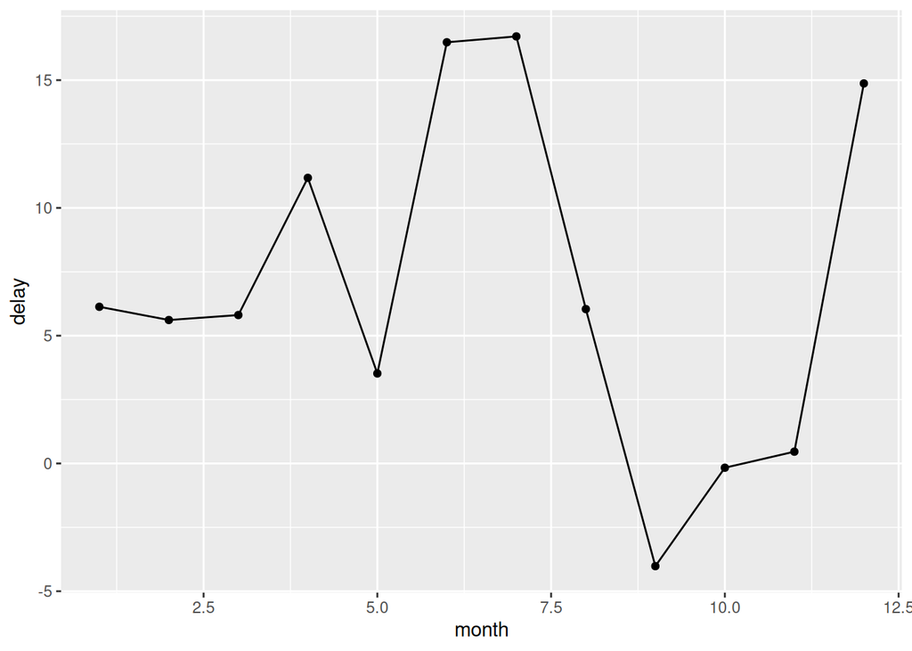

```r
flights |>
  group_by(month) |>
  summarize(
    delay = mean(arr_delay, na.rm = TRUE)
  ) |>
  ggplot(aes(x = month, y = delay)) +
  geom_point() +
  geom_line()
```

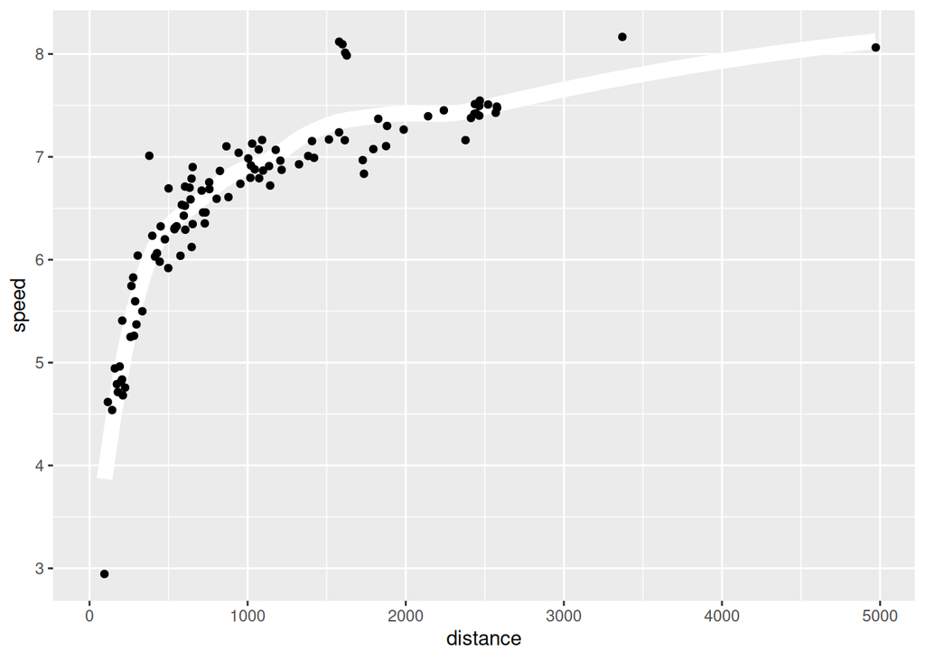

```r
flights |>
  group_by(dest) |>
  summarize(
    distance = mean(distance),
    speed = mean(distance / air_time, na.rm = TRUE)
  ) |>
  ggplot(aes(x = distance, y = speed)) +
  geom_smooth(
    method = "loess",
    span = 0.5,
    se = FALSE,
    color = "white",
    linewidth = 4
  ) +
  geom_point()
```

## 4.5 Sectioning comments

## 4.6 Exercises

### 1.

```r
flights |>
  filter(dest == "IAH") |>
  group_by(year, month, day) |>
  summarize(
    n     = n(),
    delay = mean(arr_delay, na.rm = TRUE)
  ) |>
  filter(n > 10)
```

```
# A tibble: 365 × 5
# Groups:   year, month [12]
    year month   day     n delay
   <int> <int> <int> <int> <dbl>
 1  2013     1     1    20 17.8
 2  2013     1     2    20  7
 3  2013     1     3    19 18.3
 4  2013     1     4    20 -3.2
 5  2013     1     5    13 20.2
 6  2013     1     6    18  9.28
 7  2013     1     7    19 -7.74
 8  2013     1     8    19  7.79
 9  2013     1     9    19 18.1
10  2013     1    10    19  6.68
# ℹ 355 more rows
```

```r
flights |>
  filter(
    carrier == "UA",
    dest %in% c("IAH", "HOU"),
    sched_dep_time >  0900,
    sched_arr_time < 2000
  ) |>
  group_by(flight) |>
  summarize(
    delay     = mean(arr_delay, na.rm = TRUE),
    cancelled = sum(is.na(arr_delay)),
    n         = n()
  ) |>
  filter(n > 10)
```

```
# A tibble: 74 × 4
   flight delay cancelled     n
    <int> <dbl>     <int> <int>
 1     53 12.5          2    18
 2    112 14.1          0    14
 3    205 -1.71         0    14
 4    235 -5.36         0    14
 5    255 -9.47         0    15
 6    268 38.6          1    15
 7    292  6.57         0    21
 8    318 10.7          1    20
 9    337 20.1          2    21
10    370 17.5          0    11
# ℹ 64 more rows
```

# Chapter 7 Data import

```r
library(tidyverse)
library(janitor)
library(readr)
```

## 7.2 Reading data from a file

```r
students <- read_csv("https://pos.it/r4ds-students-csv")
```

## 7.2.1 Practical advice

```r
students
```

```
# A tibble: 6 × 5
  `Student ID` `Full Name`      favourite.food     mealPlan            AGE
         <dbl> <chr>            <chr>              <chr>               <chr>
1            1 Sunil Huffmann   Strawberry yoghurt Lunch only          4
2            2 Barclay Lynn     French fries       Lunch only          5
3            3 Jayendra Lyne    N/A                Breakfast and lunch 7
4            4 Leon Rossini     Anchovies          Lunch only          <NA>
5            5 Chidiegwu Dunkel Pizza              Breakfast and lunch five
6            6 Güvenç Attila    Ice cream          Lunch only          6
```

```r
students |>
  rename(
    student_id = `Student ID`,
    full_name = `Full Name`
  )
```

```
# A tibble: 6 × 5
  student_id full_name        favourite.food     mealPlan            AGE
       <dbl> <chr>            <chr>              <chr>               <chr>
1          1 Sunil Huffmann   Strawberry yoghurt Lunch only          4
2          2 Barclay Lynn     French fries       Lunch only          5
3          3 Jayendra Lyne    N/A                Breakfast and lunch 7
4          4 Leon Rossini     Anchovies          Lunch only          <NA>
5          5 Chidiegwu Dunkel Pizza              Breakfast and lunch five
6          6 Güvenç Attila    Ice cream          Lunch only          6
```

```r
students |> janitor::clean_names()
```

```
# A tibble: 6 × 5
  student_id full_name        favourite_food     meal_plan           age
       <dbl> <chr>            <chr>              <chr>               <chr>
1          1 Sunil Huffmann   Strawberry yoghurt Lunch only          4
2          2 Barclay Lynn     French fries       Lunch only          5
3          3 Jayendra Lyne    N/A                Breakfast and lunch 7
4          4 Leon Rossini     Anchovies          Lunch only          <NA>
5          5 Chidiegwu Dunkel Pizza              Breakfast and lunch five
6          6 Güvenç Attila    Ice cream          Lunch only          6
```

```r
students |>
  janitor::clean_names() |>
  mutate(meal_plan = factor(meal_plan))
```

```
# A tibble: 6 × 5
  student_id full_name        favourite_food     meal_plan           age
       <dbl> <chr>            <chr>              <fct>               <chr>
1          1 Sunil Huffmann   Strawberry yoghurt Lunch only          4
2          2 Barclay Lynn     French fries       Lunch only          5
3          3 Jayendra Lyne    N/A                Breakfast and lunch 7
4          4 Leon Rossini     Anchovies          Lunch only          <NA>
5          5 Chidiegwu Dunkel Pizza              Breakfast and lunch five
6          6 Güvenç Attila    Ice cream          Lunch only          6
```

```r
students <- students |>
  janitor::clean_names() |>
  mutate(
    meal_plan = factor(meal_plan),
    age = parse_number(if_else(age == "five", "5", as.character(age)))
  )
```

## 7.2.2 Other arguments

```r
read_csv(
  "a,b,c
  1,2,3
  4,5,6"
)
```

```
# A tibble: 2 × 3
      a     b     c
  <dbl> <dbl> <dbl>
1     1     2     3
2     4     5     6
```

```r
read_csv(
  "The first line of metadata
  The second line of metadata
  x,y,z
  1,2,3",
  skip = 2
)
```

```
# A tibble: 1 × 3
      x     y     z
  <dbl> <dbl> <dbl>
1     1     2     3
```

```r
read_csv(
  "# A comment I want to skip
  x,y,z
  1,2,3",
  comment = "#"
)
```

```
# A tibble: 1 × 3
      x     y     z
  <dbl> <dbl> <dbl>
1     1     2     3
```

```r
read_csv(
  "1,2,3
  4,5,6",
  col_names = FALSE
)
```

```
# A tibble: 2 × 3
     X1    X2    X3
  <dbl> <dbl> <dbl>
1     1     2     3
2     4     5     6
```

```r
read_csv(
  "1,2,3
  4,5,6",
  col_names = c("x", "y", "z")
)
```

```
# A tibble: 2 × 3
      x     y     z
  <dbl> <dbl> <dbl>
1     1     2     3
2     4     5     6
```

## 7.2.4 Exercises

### 1.

To read a file where fields are separated with a “|” I can use the read_delim() function. This tells R to treat “|” as the delimiter between fields. You can also specify other arguments like col_names, na, or skip if needed.

### 2.

**Common arguments between `read_csv()` and `read_tsv()`**

- col_names
- col_types
- na
- locale
- quote

### 3.

**Most important arguments to `read_fwf()`**

- file
- col_postions
  - fwf_width()
  - fwf_postions()
  - fwf_empty
- col_names
- skip
- na
- locale
- n_max

### 4.

To correctly read the text `"x,y\n1,'a,b'"` into a data frame using `read_csv()`, you need to specify the `quote` argument to match the quoting character used in the string, in this case, a single quote `'`.

read_csv(“x,y,‘a,b’”, quote = “’”)

The string `'a,b'` contains a comma, so it must be enclosed in quotes to be treated as a single field. By default, `read_csv()` expects double quotes (`"`), so it misinterprets `'a,b'` unless you explicitly tell it to treat `'` as the quoting character.

### 5.

1. read_csv(“a,b\n1,2,3\n4,5,6”)
   - The problem is each row has three values, but the header only defines two columns. The code results in a warning stating 3 columns were found on row 2; expected 2” It will still read the file, but the third value goes into a column named 3.
2. read_csv(“a,b,c\n1,2\n1,2,3,4”)
   - The problem is row 2 has only two values (missing one) and row 3 has four values (one extra). Running the code results in an error stating “2 columns were found on row 2; expected 3” and “4 columns were found on row 3; expected 3”
3. read_csv(“a,b\n\”1”)
   - The issues is the unclosed quote, the string `"1` starts a quoted field but never ends. This results in embedded nulls found in input” or “Unclosed quoted string” and parsing fails entirely.
4. read_csv(“a,b\n1,2\na,b”)
   - The problem is Row 3 contains non-numeric values (`a`, `b`) under columns that were inferred as numeric from row 2. The code results in an error stating “Inconsistent types — expected numeric, got character.” It coerces the entire column to character and may show `NA` for incompatible values.
5. read_csv(“a;b\n1;3”)
   - The problem is the delimiter used is `;`, but `read_csv()` expects commas. This results in the code reading the entire line as a single column named `"a;b"` with values `"1;3"`.

### 6.

```r
annoying <- tibble(
  `1` = 1:10,
  `2` = `1` * 2 + rnorm(length(`1`))
)
```

#### a.

```r
annoying |> pull(`1`)
```

```
 [1]  1  2  3  4  5  6  7  8  9 10
```

#### b.

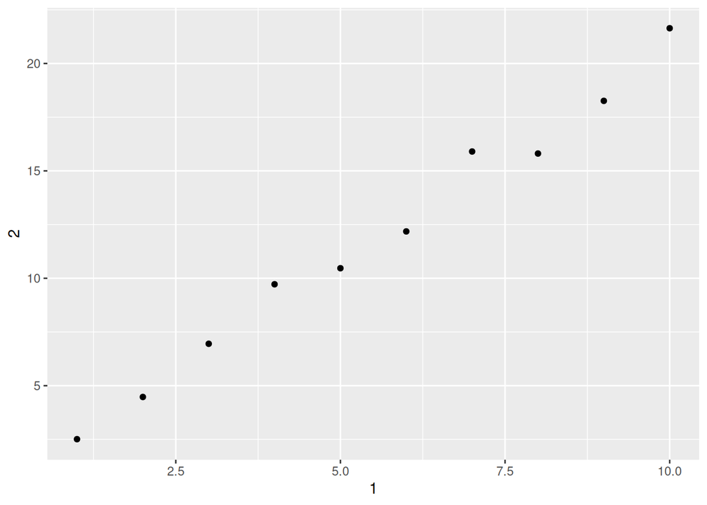

```r
ggplot(annoying, aes(x = `1`, y = `2`)) +
  geom_point()
```

#### c.

```r
annoying <- tibble(
  `1` = 1:10
) |>
  mutate(`2` = `1` * 2 + rnorm(length(`1`)))
```

```r
annoying |>
  mutate(`3` = `2` / `1`)
```

```
# A tibble: 10 × 3
     `1`   `2`   `3`
   <int> <dbl> <dbl>
 1     1  1.54  1.54
 2     2  3.82  1.91
 3     3  6.13  2.04
 4     4  8.05  2.01
 5     5 10.6   2.13
 6     6 11.4   1.90
 7     7 13.9   1.99
 8     8 15.4   1.92
 9     9 17.7   1.97
10    10 21.3   2.13
```

#### d.

```r
annoying <- tibble(
  `1` = 1:10
) |>
  mutate(`2` = `1` * 2 + rnorm(length(`1`))) |>
  mutate(`3` = `2` / `1`) |>
  rename(
    one   = `1`,
    two   = `2`,
    three = `3`
  )
```

## 7.3 Controlling column types

```r
read_csv("
  logical,numeric,date,string
  TRUE,1,2021-01-15,abc
  false,4.5,2021-02-15,def
  T,Inf,2021-02-16,ghi
")
```

```
# A tibble: 3 × 4
  logical numeric date       string
  <lgl>     <dbl> <date>     <chr>
1 TRUE        1   2021-01-15 abc
2 FALSE       4.5 2021-02-15 def
3 TRUE      Inf   2021-02-16 ghi
```

## 7.3.2 Missing values, column types, and problems

```r
simple_csv <- "
  x
  10
  .
  20
  30"
```

```r
read_csv(simple_csv)
```

```
# A tibble: 4 × 1
  x
  <chr>
1 10
2 .
3 20
4 30
```

```r
df <- read_csv(
  simple_csv,
  col_types = list(x = col_double())
)
```

```r
problems(df)
```

```
# A tibble: 1 × 5
    row   col expected actual file
  <int> <int> <chr>    <chr>  <chr>
1     3     1 a double .      /tmp/RtmpF8LC5x/file39a31e59d94465
```

```r
read_csv(simple_csv, na = ".")
```

```
# A tibble: 4 × 1
      x
  <dbl>
1    10
2    NA
3    20
4    30
```

## 7.3.3 Column types

```r
another_csv <- "
x,y,z
1,2,3"

read_csv(
  another_csv,
  col_types = cols(.default = col_character())
)
```

```
# A tibble: 1 × 3
  x     y     z
  <chr> <chr> <chr>
1 1     2     3
```

```r
read_csv(
  another_csv,
  col_types = cols_only(x = col_character())
)
```

```
# A tibble: 1 × 1
  x
  <chr>
1 1
```

## 7.4 Reading data from multiple files

```r
sales_files <- c(
  "https://pos.it/r4ds-01-sales",
  "https://pos.it/r4ds-02-sales",
  "https://pos.it/r4ds-03-sales"
)
read_csv(sales_files, id = "file")
```

```
# A tibble: 19 × 6
   file                         month     year brand  item     n
   <chr>                        <chr>    <dbl> <dbl> <dbl> <dbl>
 1 https://pos.it/r4ds-01-sales January   2019     1  1234     3
 2 https://pos.it/r4ds-01-sales January   2019     1  8721     9
 3 https://pos.it/r4ds-01-sales January   2019     1  1822     2
 4 https://pos.it/r4ds-01-sales January   2019     2  3333     1
 5 https://pos.it/r4ds-01-sales January   2019     2  2156     9
 6 https://pos.it/r4ds-01-sales January   2019     2  3987     6
 7 https://pos.it/r4ds-01-sales January   2019     2  3827     6
 8 https://pos.it/r4ds-02-sales February  2019     1  1234     8
 9 https://pos.it/r4ds-02-sales February  2019     1  8721     2
10 https://pos.it/r4ds-02-sales February  2019     1  1822     3
11 https://pos.it/r4ds-02-sales February  2019     2  3333     1
12 https://pos.it/r4ds-02-sales February  2019     2  2156     3
13 https://pos.it/r4ds-02-sales February  2019     2  3987     6
14 https://pos.it/r4ds-03-sales March     2019     1  1234     3
15 https://pos.it/r4ds-03-sales March     2019     1  3627     1
16 https://pos.it/r4ds-03-sales March     2019     1  8820     3
17 https://pos.it/r4ds-03-sales March     2019     2  7253     1
18 https://pos.it/r4ds-03-sales March     2019     2  8766     3
19 https://pos.it/r4ds-03-sales March     2019     2  8288     6
```

```r
sales_files <- list.files("data", pattern = "sales\\.csv$", full.names = TRUE)
sales_files
```

```
character(0)
```

## 7.5 Writing to a file

```r
write_csv(students, "students.csv")
```

```r
students
```

```
# A tibble: 6 × 5
  student_id full_name        favourite_food     meal_plan             age
       <dbl> <chr>            <chr>              <fct>               <dbl>
1          1 Sunil Huffmann   Strawberry yoghurt Lunch only              4
2          2 Barclay Lynn     French fries       Lunch only              5
3          3 Jayendra Lyne    N/A                Breakfast and lunch     7
4          4 Leon Rossini     Anchovies          Lunch only             NA
5          5 Chidiegwu Dunkel Pizza              Breakfast and lunch     5
6          6 Güvenç Attila    Ice cream          Lunch only              6
```

```r
write_csv(students, "students-2.csv")
read_csv("students-2.csv")
```

```
# A tibble: 6 × 5
  student_id full_name        favourite_food     meal_plan             age
       <dbl> <chr>            <chr>              <chr>               <dbl>
1          1 Sunil Huffmann   Strawberry yoghurt Lunch only              4
2          2 Barclay Lynn     French fries       Lunch only              5
3          3 Jayendra Lyne    N/A                Breakfast and lunch     7
4          4 Leon Rossini     Anchovies          Lunch only             NA
5          5 Chidiegwu Dunkel Pizza              Breakfast and lunch     5
6          6 Güvenç Attila    Ice cream          Lunch only              6
```

```r
write_rds(students, "students.rds")
read_rds("students.rds")
```

```
# A tibble: 6 × 5
  student_id full_name        favourite_food     meal_plan             age
       <dbl> <chr>            <chr>              <fct>               <dbl>
1          1 Sunil Huffmann   Strawberry yoghurt Lunch only              4
2          2 Barclay Lynn     French fries       Lunch only              5
3          3 Jayendra Lyne    N/A                Breakfast and lunch     7
4          4 Leon Rossini     Anchovies          Lunch only             NA
5          5 Chidiegwu Dunkel Pizza              Breakfast and lunch     5
6          6 Güvenç Attila    Ice cream          Lunch only              6
```

```r
library(arrow)
write_parquet(students, "students.parquet")
read_parquet("students.parquet")
```

```
# A tibble: 6 × 5
  student_id full_name        favourite_food     meal_plan             age
       <dbl> <chr>            <chr>              <fct>               <dbl>
1          1 Sunil Huffmann   Strawberry yoghurt Lunch only              4
2          2 Barclay Lynn     French fries       Lunch only              5
3          3 Jayendra Lyne    N/A                Breakfast and lunch     7
4          4 Leon Rossini     Anchovies          Lunch only             NA
5          5 Chidiegwu Dunkel Pizza              Breakfast and lunch     5
6          6 Güvenç Attila    Ice cream          Lunch only              6
```

## 7.6 Data entry

```r
tibble(
  x = c(1, 2, 5),
  y = c("h", "m", "g"),
  z = c(0.08, 0.83, 0.60)
)
```

```
# A tibble: 3 × 3
      x y         z
  <dbl> <chr> <dbl>
1     1 h      0.08
2     2 m      0.83
3     5 g      0.6
```

```r
tribble(
  ~x, ~y, ~z,
  1, "h", 0.08,
  2, "m", 0.83,
  5, "g", 0.60
)
```

```
# A tibble: 3 × 3
      x y         z
  <dbl> <chr> <dbl>
1     1 h      0.08
2     2 m      0.83
3     5 g      0.6
```